# TP LEROY

Tommy Tankhapanya Chloé Landais Guibert Samuel

Pour le 19/02/2021

# TP - ANOVA

#### Les données proviennent d’un organisme qui étudie le budget familial hebdomadaire allouées aux repas. L’étude s’intéresse à plusieurs facteurs : la taille de la famille et la catégorie socioprofessionelle. L’enquête dont sont issues nos donnes permet de classes les familles en 15 catégories obtenues par croisement de la CSP et de la taille de la famille.

#### Les modalités de la variable nombre d’enfants sont :

- Familles sans enfant
- Familles ayant 1 ou 2 enfants
- Familles ayant 3 ou 4 enfants
- Familles ayant 5 ou 6 enfants
- Familles ayant plus de 6 enfants

#### Nous avons pour la CSP les modalités suivantes :

- CSP1
- CSP2
- CSP3

#### Le lien entre ces variables est assez compliqués à expliquer puisqu’un grand nombre d’enfant signifie plus de bouches à nourir et donc une augmentation du budget hebdomadaire. Cependant, une grande famille poura bénéficier d’économie d’échelle en achetant en gros. De plus, ce sont les familles les plus pauvres et les plus riches qui ont davantage d’enfant en France.

#### Dans notre étude, nous allons essayer mettre en exergue le lien entre le budget hebdomaire des ménages et le nombre d’enfants ainsi que la catégorie socio-professionnelle.

```
## # A tibble: 15 x 3
## # Groups:   Famille [5]
##    Famille             CSP       n
##    <fct>               <chr> <int>
##  1 " Sans enfant"      CSP1     10
##  2 " Sans enfant"      CSP2     10
##  3 " Sans enfant"      CSP3     10
##  4 " 1 ou 2 enfants"   CSP1     10
##  5 " 1 ou 2 enfants"   CSP2     10
##  6 " 1 ou 2 enfants"   CSP3     10
##  7 "  3 ou 4 enfants"  CSP1     10
##  8 "  3 ou 4 enfants"  CSP2     10
##  9 "  3 ou 4 enfants"  CSP3     10
## 10 "5 ou 6 enfants"    CSP1     10
## 11 "5 ou 6 enfants"    CSP2     10
## 12 "5 ou 6 enfants"    CSP3     10
## 13 "Plus de 6 enfants" CSP1     10
## 14 "Plus de 6 enfants" CSP2     10
## 15 "Plus de 6 enfants" CSP3     10
```

#### Grâce aux tableaux ci-dessus, on constate une répartition parfaitement équitable. On a 30 familles dans chaque modalités de la variable nombre d’enfants et dans ces groupes, 10 familles de chaque CSP.

### Budget des familles en fonction du nombre d’enfants

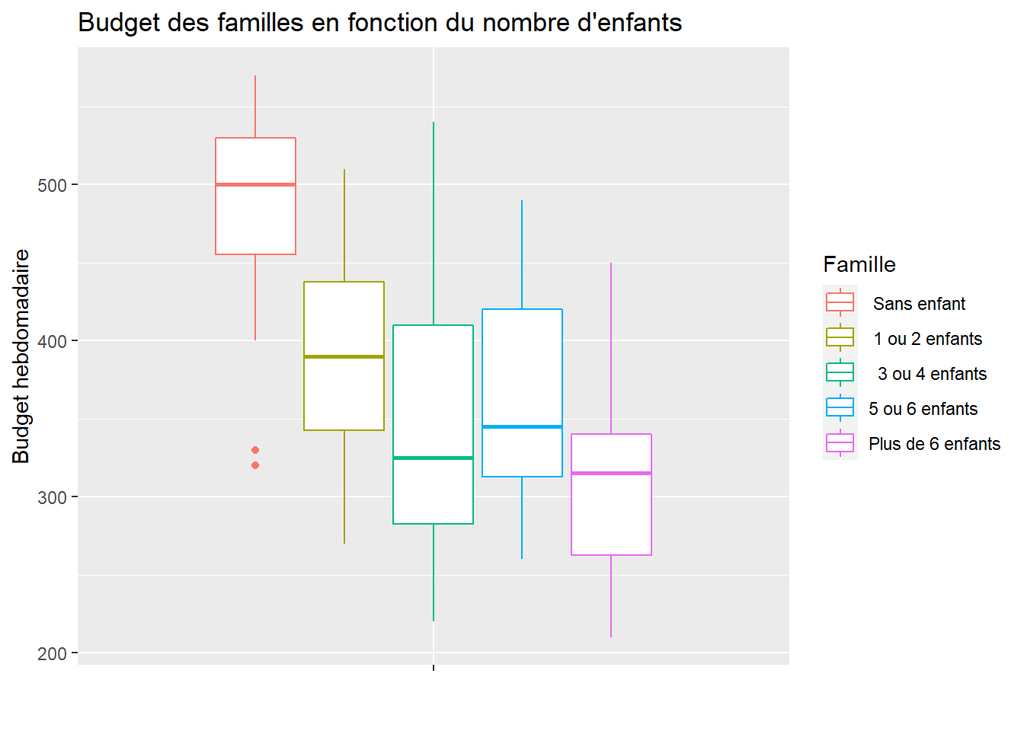

```
## # A tibble: 5 x 6
##   Famille             Moyenne Mediane `Ecart-type` maximun minimun
##   <fct>                 <dbl>   <dbl>        <dbl>   <dbl>   <dbl>
## 1 " Sans enfant"         486.     500           64     570     320
## 2 " 1 ou 2 enfants"      392.     390           62     510     270
## 3 "  3 ou 4 enfants"     340.     325           75     540     220
## 4 "5 ou 6 enfants"       360      345           63     490     260
## 5 "Plus de 6 enfants"    308.     315           63     450     210
```

#### De manière générale, plus le nombre d’endant augmente plus le revenu de la famille diminue. En effet, 50% des familles sans enfant ont un budget de 500 € ou plus par semaine contre 315 € pour les familles de plus de 6 enfants.

### Budget des familles en fonction de la CSP

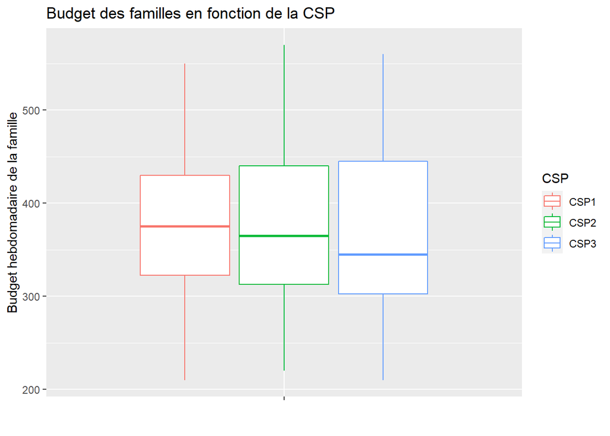

```
## # A tibble: 3 x 6
##   CSP   Moyenne Mediane `Ecart-type` maximun minimun
##   <chr>   <dbl>   <dbl>        <dbl>   <dbl>   <dbl>
## 1 CSP1     382.     375           87     550     210
## 2 CSP2     376      365           88     570     220
## 3 CSP3     374.     345           93     560     210
```

#### On constate qu’il existe très peu de différence de budget hebdomadaire entre les différentes CSP de notre jeu de données.

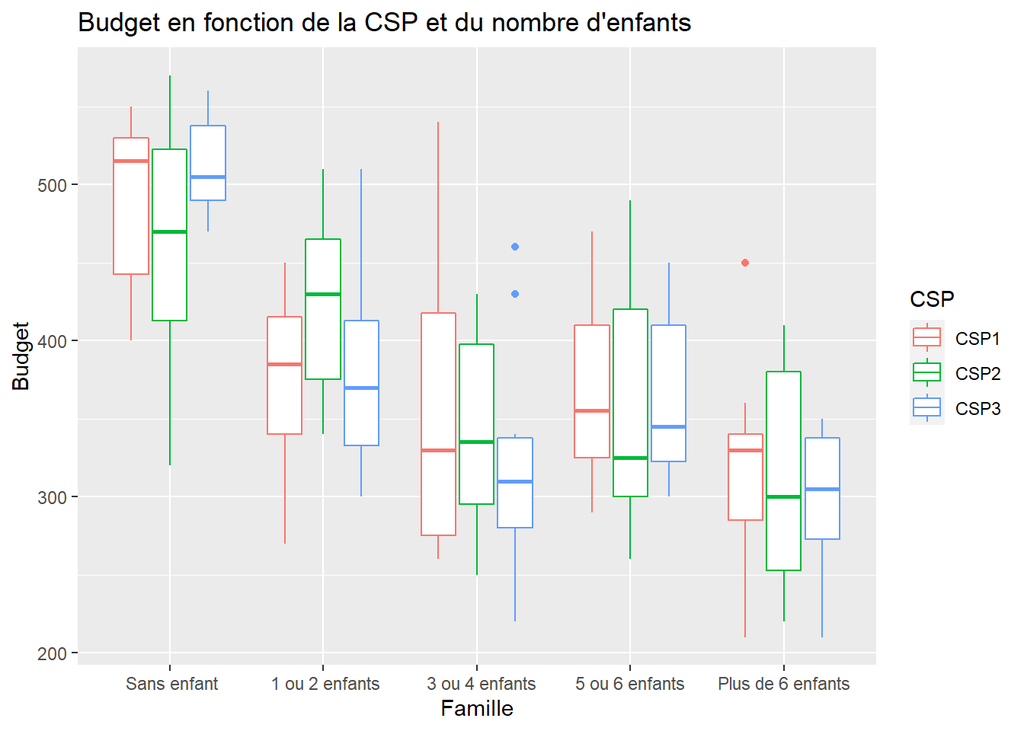

### Tableau récapitulatif

```
## # A tibble: 15 x 5
## # Groups:   Famille [5]
##    Famille             CSP   Moyenne Mediane `Ecart-type`
##    <fct>               <chr>   <dbl>   <dbl>        <dbl>
##  1 " Sans enfant"      CSP1      490     515           57
##  2 " Sans enfant"      CSP2      455     470           85
##  3 " Sans enfant"      CSP3      512     505           31
##  4 " 1 ou 2 enfants"   CSP1      379     385           57
##  5 " 1 ou 2 enfants"   CSP2      422     430           58
##  6 " 1 ou 2 enfants"   CSP3      376     370           65
##  7 "  3 ou 4 enfants"  CSP1      355     330           92
##  8 "  3 ou 4 enfants"  CSP2      342     335           60
##  9 "  3 ou 4 enfants"  CSP3      322     310           74
## 10 "5 ou 6 enfants"    CSP1      367     355           58
## 11 "5 ou 6 enfants"    CSP2      351     325           82
## 12 "5 ou 6 enfants"    CSP3      362     345           53
## 13 "Plus de 6 enfants" CSP1      318     330           67
## 14 "Plus de 6 enfants" CSP2      310     300           74
## 15 "Plus de 6 enfants" CSP3      297     305           49
```

### Modèle complet

#### Après avoir étudié nos données de façon descriptives, nous passons à une étude plus approfondie.

```
##
## Call:
## lm(formula = Budget ~ ., data = df)
##
## Residuals:
##     Min      1Q  Median      3Q     Max
## -164.47  -48.47   -1.70   46.68  195.73
##
## Coefficients:
##                          Estimate Std. Error t value Pr(>|t|)
## (Intercept)                490.27      14.24  34.437  < 2e-16 ***
## Famille 1 ou 2 enfants     -93.33      17.02  -5.485 1.82e-07 ***
## Famille  3 ou 4 enfants   -146.00      17.02  -8.580 1.43e-14 ***
## Famille5 ou 6 enfants     -125.67      17.02  -7.385 1.15e-11 ***
## FamillePlus de 6 enfants  -177.33      17.02 -10.422  < 2e-16 ***
## CSPCSP2                     -5.80      13.18  -0.440    0.661
## CSPCSP3                     -8.00      13.18  -0.607    0.545
## ---
## Signif. codes:  0 '***' 0.001 '**' 0.01 '*' 0.05 '.' 0.1 ' ' 1
##
## Residual standard error: 65.9 on 143 degrees of freedom
## Multiple R-squared:  0.4719, Adjusted R-squared:  0.4497
## F-statistic:  21.3 on 6 and 143 DF,  p-value: < 2.2e-16
```

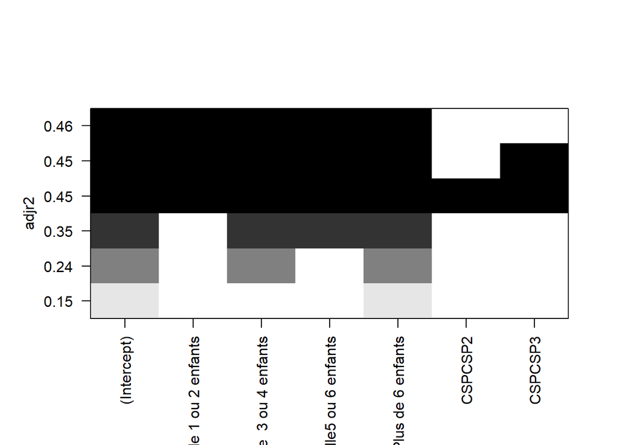

#### On souhaite à présent réaliser une anova. Pour cela, nous devons vérifier les trois conditions suivnates :

- 1. Les résidus sont indépendants.

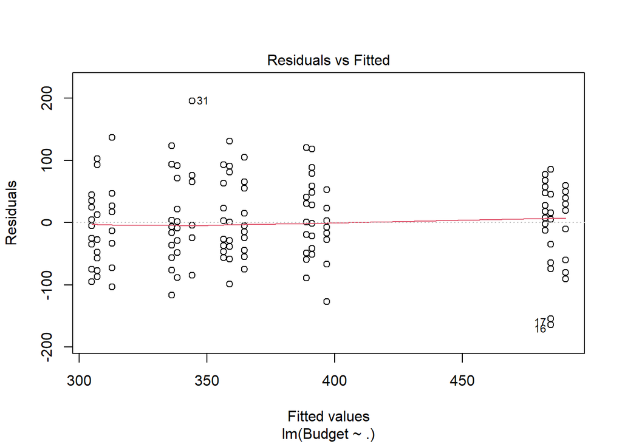

```
##  lag Autocorrelation D-W Statistic p-value
##    1       0.1963508      1.602304   0.004
##  Alternative hypothesis: rho != 0
```

- 2. Les resiodus de la variable quantitative étudiée suit une loi normale de moyenne 0 dans les p populations comparées.

```
##
##  Shapiro-Wilk normality test
##
## data:  reg$residuals
## W = 0.99416, p-value = 0.8095
```

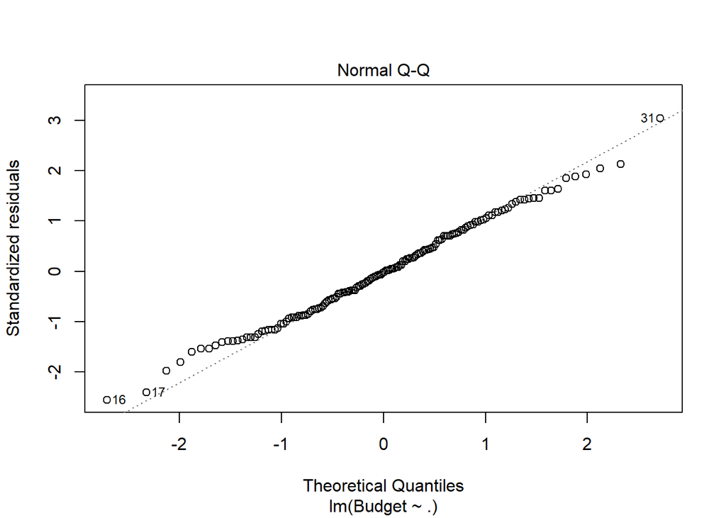

#### D’après le test de de Shapiro et le graphique ci-dessus, les résidus de la variable quantitative (Budget) étudié suivent globalement une loi normale. On remarque une variabilité aux extremités mais cela est négligable.

- 3. Les p populations comparées ont même variance : Homogénéité des variances ou homoscédasticité.

```
##
##  Bartlett test of homogeneity of variances
##
## data:  df$Budget by df$Famille
## Bartlett's K-squared = 1.5147, df = 4, p-value = 0.824
```

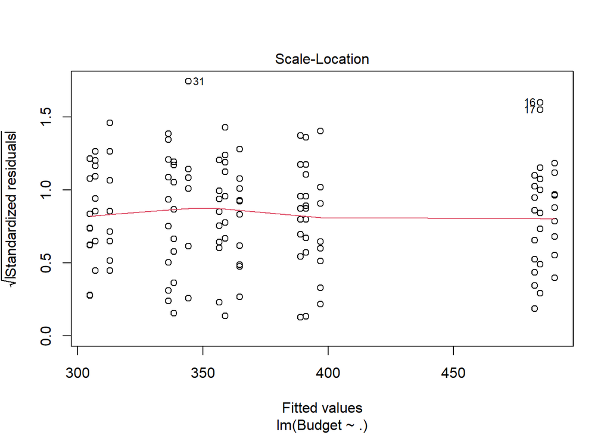

#### D’après le graphique et le test de Berthelet, on ne rejette pas l’égalité des variances. En effet, la p-valeur du test est supérieure à 5% et la dispertion des résidus est globalement identique pour chaque modalités.

```
## Analysis of Variance Table
##
## Response: Budget
##            Df Sum Sq Mean Sq F value Pr(>F)
## Famille     4 553237  138309 31.8450 <2e-16 ***
## CSP         2   1708     854  0.1966 0.8217
## Residuals 143 621079    4343
## ---
## Signif. codes:  0 '***' 0.001 '**' 0.01 '*' 0.05 '.' 0.1 ' ' 1
```

#### D’après les résultats obtenus de l’ANOVA, on demontre une différence du budget hebdomadaire en fonction de la taille de la famille. En effet, nous relevons une p-valeur très proche de 0. Par ailleurs, la p-valeur de la catégorie socio-professionnelle est relativement élevée ; on peut alors admettre que le budget ne diffère pas selon la CSP.

### Conclusion avancée:

#### D’après l’anova et la régréssion linéaire, plus le nombre d’enfants augmente, plus le budget hebdomadaire des ménages diminue. Les limites de cette étude sont le fait qu’il n’y est pas d’avantage de CSP et qu’elles ne sont pas nommées clairement, le fait qu’il n’y pas la variable âge de l’enfant pose des biais.

### Conclusion générale:

#### Plus le nombre d’enfants augmente, plus le budget hebdomadaire des ménages diminue. La CSP n’a que peu d’importance sur le budget hebdomadaire. D’après nous, la CSP1 représente les professions intermédiaires ou les professions intelectuels supérieurs et assimilées. La CSP2 représenterait les ouvriers et la CSP3 les employés. En effet, la CSP2 à une budget très légerement supérieur à la CSP2. Or, les ouvriers ont un salaire moyen très légérement supérieur aux employés.